# Introduction to R Markdown

Shih Ching Fu

ResBaz Perth 2019

# Welcome

In this session we’ll get a brief introduction to R Markdown.

The materials are taken from:

- [R for Data Science](https://r4ds.had.co.nz/) (Grolemund and Wickham 2017)
- [R for Reproducible Scientific Analysis](http://swcarpentry.github.io/r-novice-gapminder/) (Wright and Zimmerman 2016)
- [R Markdown: The Definitive Guide](https://bookdown.org/yihui/rmarkdown/) (Xie, Allaire, and Grolemund 2018)
- [R Markdown](https://rmarkdown.rstudio.com/lesson-1.html) (RStudio 2018)

## Objectives

1. Be able to create a R Notebook from scratch in RStudio
2. Knit a cheatsheet of commonly used R Markdown commands
3. Know where to get further information on more advanced R Markdown usage

## Introduction

During your data analysis work you’ll undoubtedly need to produce reports of your analysis and findings. Ideally these should be reproducible documents in the sense that should you wish to update the results, you can simply re-compile the report instead of having to manually reconstruct figures.

R Markdown, via the knitr package, allows us to embed code into documents such that it gets executed and results such as graphs and figures interleaved with text. Documents can be in various formats such as HTML, LaTeX, or Word, and other types such as slideshows, webpages, and even books.

R Markdown files are designed to be used in three ways:

1. For communicating to decision makers, who want to focus on the conclusions, not the code behind the analysis.
2. For collaborating with other data scientists (including future you!), who are interested in both your conclusions, and how you reached them ( i.e. the code).
3. As an environment in which to do data science, as a modern day lab notebook where you can capture not only what you did, but also what you were thinking.

## Creating an R Notebook

1. Launch RStudio
2. File menu
3. New File > R Notebook

## Knitting an R Notebook

When you knit the document, R Markdown sends the .Rmd file to knitr, http://yihui.name/knitr/, which executes all of the code chunks and creates a new markdown (.md) document which includes the code and its output. The markdown file generated by knitr is then processed by pandoc, http://pandoc.org/, which is responsible for creating the finished file. The advantage of this two step workflow is that you can create a very wide range of output formats, as you’ll learn about in R markdown formats.

Click on the Knit button.

# Structure of an .Rmd file

- Formatted text
- Code chunks
- YAML header

## Text Formatting

Text in .Rmd files are written in Markdown which is designed to be easy to write and human-readable even before it’s converted into HTML or richer formats.

*italic* or *italic* **bold** or **bold** *bold and italic* or *bold and italic* `code` superscript<sup>2</sup> subscript<sub>2</sub>

### Headings

`# 1st Level Header`

`## 2nd Level Header`

`### 3rd Level Header`

### Lists

- Bulleted list item 1
- Item 2
  - Item 2a
  - Item 2b
1. Numbered list item 1
2. Item 2. The numbers are incremented automatically in the output.

### Links and Images

http://example.com

[linked phrase](http://example.com)

optional caption text

### Tables

| First Header | Second Header |
| --- | --- |
| Content Cell | Content Cell |
| Content Cell | Content Cell |

```r
head(iris)
```

```
##   Sepal.Length Sepal.Width Petal.Length Petal.Width Species
## 1          5.1         3.5          1.4         0.2  setosa
## 2          4.9         3.0          1.4         0.2  setosa
## 3          4.7         3.2          1.3         0.2  setosa
## 4          4.6         3.1          1.5         0.2  setosa
## 5          5.0         3.6          1.4         0.2  setosa
## 6          5.4         3.9          1.7         0.4  setosa
```

## LaTeX

Euler’s identity, $1 + e^{-\pi i} = 0$, contains five fundamental mathematical constants.

Equations can be put on their own line
$$P(A_i | B) = \frac{P(B|A_i)P(A_i)}{\sum_j P(B | A_j)P(A_j)}$$

## Code Chunks

Code chunks are prefixed and suffixed by three back-ticks ‘`’. The curly brackets contain various parameters and options for the chunk.

`` ```{r} `` `summary(iris)` `` ``` ``

```r
summary(iris)
```

```
##   Sepal.Length    Sepal.Width     Petal.Length    Petal.Width
##  Min.   :4.300   Min.   :2.000   Min.   :1.000   Min.   :0.100
##  1st Qu.:5.100   1st Qu.:2.800   1st Qu.:1.600   1st Qu.:0.300
##  Median :5.800   Median :3.000   Median :4.350   Median :1.300
##  Mean   :5.843   Mean   :3.057   Mean   :3.758   Mean   :1.199
##  3rd Qu.:6.400   3rd Qu.:3.300   3rd Qu.:5.100   3rd Qu.:1.800
##  Max.   :7.900   Max.   :4.400   Max.   :6.900   Max.   :2.500
##        Species
##  setosa    :50
##  versicolor:50
##  virginica :50
##
##
##
```

### Chunk options

The `r` indicates this chunk contains R code. R Notebooks could run python or bash code if need be. Next comes any R code such as plotting and the chunk is closed by three more back-ticks.

Show only the code but don’t execute it and thus have no output

```r
summary(iris)
```

Show the output but don’t show the code:

```
##   Sepal.Length    Sepal.Width     Petal.Length    Petal.Width
##  Min.   :4.300   Min.   :2.000   Min.   :1.000   Min.   :0.100
##  1st Qu.:5.100   1st Qu.:2.800   1st Qu.:1.600   1st Qu.:0.300
##  Median :5.800   Median :3.000   Median :4.350   Median :1.300
##  Mean   :5.843   Mean   :3.057   Mean   :3.758   Mean   :1.199
##  3rd Qu.:6.400   3rd Qu.:3.300   3rd Qu.:5.100   3rd Qu.:1.800
##  Max.   :7.900   Max.   :4.400   Max.   :6.900   Max.   :2.500
##        Species
##  setosa    :50
##  versicolor:50
##  virginica :50
##
##
##
```

Execute the code but don’t show results in the report.

## Slide with Plot

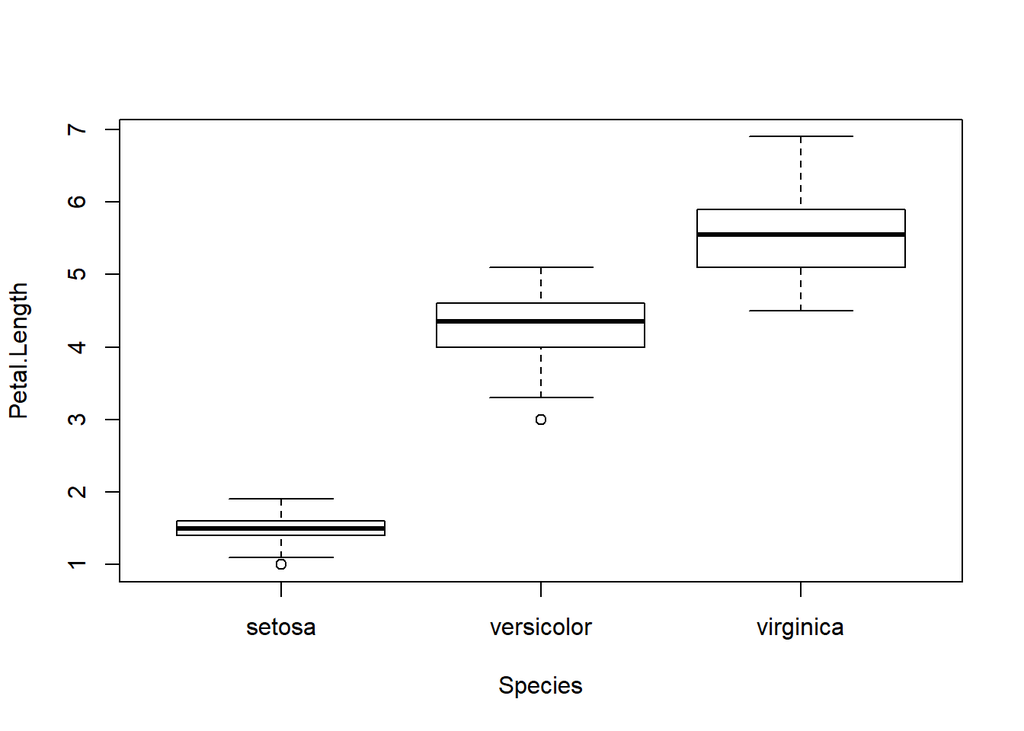

```r
boxplot(Petal.Length ~ Species, data = iris)
```

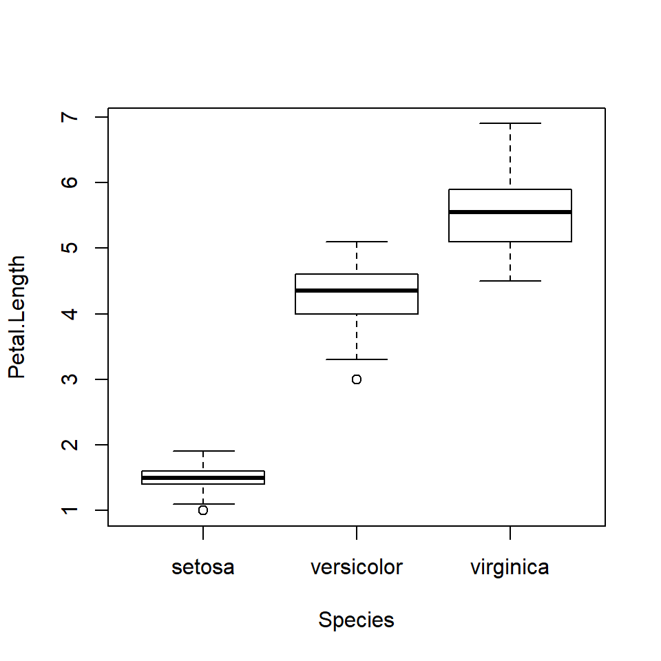

```r
boxplot(Petal.Length ~ Species, data = iris)
```

## Inline R code

The `iris` dataset has 150 rows.

## YAML

The beginning of an R Markdown file looks like this:

`---` `title: "R Notebook"` `output: html_notebook` `---`

Let’s add our name as author and today’s date.

`---` `title: "R Notebook"` `author: "Shih Ching Fu"`  
`date: "4 July 2019"`  
`output: html_notebook` `---`

## Create a bibliography

`---` `title: "R Notebook"` `author: "Shih Ching Fu"`  
`date: "4 July 2019"`  
`output: html_notebook` `bibliography: ref.bib` `---`

## References

Grolemund, Garrett, and Hadley Wickham. 2017. *R for Data Science*. O’Reilly Media.

RStudio. 2018. “R Markdown.” https://rmarkdown.rstudio.com/index.html.

Wright, Thomas, and Naupaka Zimmerman, eds. 2016. “Software Carpentry: R for Reproducible Scientific Analysis.” https://doi.org/10.5281/zenodo.57520.

Xie, Yihui, J.J. Allaire, and Garrett Grolemund. 2018. *R Markdown: The Definitive Guide*. CRC Press.